# EEW Congressional Report Card

[figure not shown]

Map shows congressional district with clusters of regulated facilities

###### Report Generated September 15th, 2020

###### Disclaimer: Data included herein were drawn from EPA’s publicly available Enforcement and Compliance History Online ECHO database on August 25, 2020. EDGI has no control over the nature, content, or sustained availability of this database. While EDGI works to assure that the information in this report is correct, that information is subject to limitations of the ECHO database, and is provided “as is.” EDGI makes no representations or warranties of any kind, express or implied, about the completeness or reliability of this information. The information and images within this report are for general information purposes only. To examine this data for yourself you can view our analysis here and re-run it here.

#### DRAFT not for circulation

# Facilities in your District

These figures show the number of quarters the highest-violating facilities have been in violation over the last 3 years. These quarters are not necessarily consecutive.

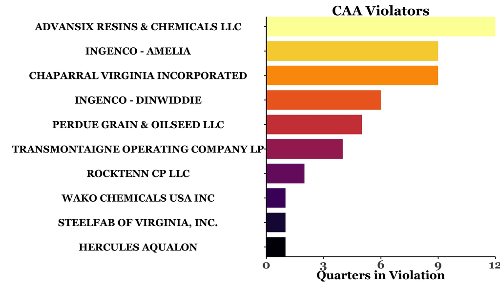

### ECHO reports for these facilities:

- [ADVANSIX RESINS & CHEMICALS LLC](http://echo.epa.gov/detailed-facility-report?fid=110000620221)
- [CHAPARRAL VIRGINIA INCORPORATED](http://echo.epa.gov/detailed-facility-report?fid=110002097766)
- [INGENCO - AMELIA](http://echo.epa.gov/detailed-facility-report?fid=110002373146)
- [INGENCO - DINWIDDIE](http://echo.epa.gov/detailed-facility-report?fid=110007008102)
- [PERDUE GRAIN & OILSEED LLC](http://echo.epa.gov/detailed-facility-report?fid=110001888841)
- [TRANSMONTAIGNE OPERATING COMPANY LP](http://echo.epa.gov/detailed-facility-report?fid=110000885800)
- [ROCKTENN CP LLC](http://echo.epa.gov/detailed-facility-report?fid=110012503781)
- [HERCULES AQUALON](http://echo.epa.gov/detailed-facility-report?fid=110000342665)
- [STEELFAB OF VIRGINIA, INC.](http://echo.epa.gov/detailed-facility-report?fid=110000342576)
- [WAKO CHEMICALS USA INC](http://echo.epa.gov/detailed-facility-report?fid=110000341979)

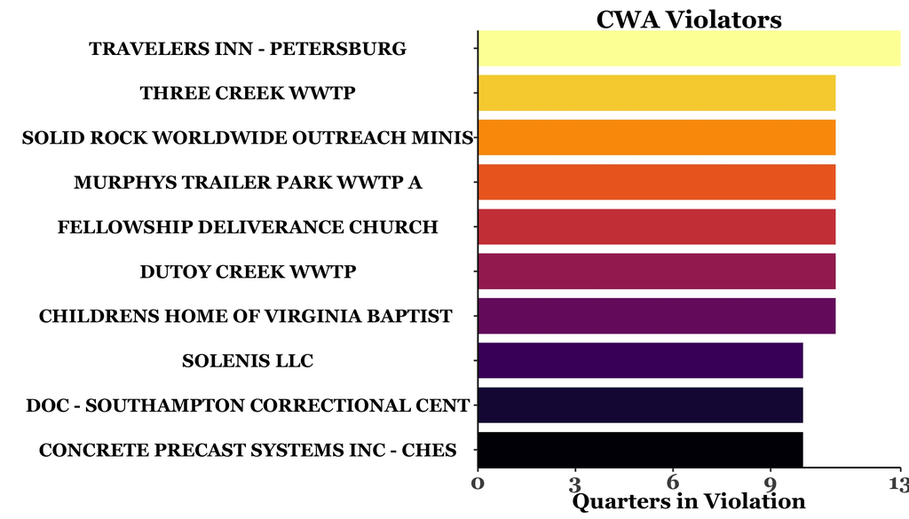

### ECHO reports for these facilities:

- [TRAVELERS INN - PETERSBURG](http://echo.epa.gov/detailed-facility-report?fid=110062647621)
- [DUTOY CREEK WWTP](http://echo.epa.gov/detailed-facility-report?fid=110015314284)
- [CHILDRENS HOME OF VIRGINIA BAPTIST](http://echo.epa.gov/detailed-facility-report?fid=110010915956)
- [SOLID ROCK WORLDWIDE OUTREACH MINIS](http://echo.epa.gov/detailed-facility-report?fid=110070598260)
- [MURPHYS TRAILER PARK WWTP A](http://echo.epa.gov/detailed-facility-report?fid=110070601344)
- [THREE CREEK WWTP](http://echo.epa.gov/detailed-facility-report?fid=110039940696)
- [FELLOWSHIP DELIVERANCE CHURCH](http://echo.epa.gov/detailed-facility-report?fid=110070598556)
- [DOC - SOUTHAMPTON CORRECTIONAL CENT](http://echo.epa.gov/detailed-facility-report?fid=110005246634)
- [CONCRETE PRECAST SYSTEMS INC - CHES](http://echo.epa.gov/detailed-facility-report?fid=110002342787)
- [SOLENIS LLC](http://echo.epa.gov/detailed-facility-report?fid=110070828262)

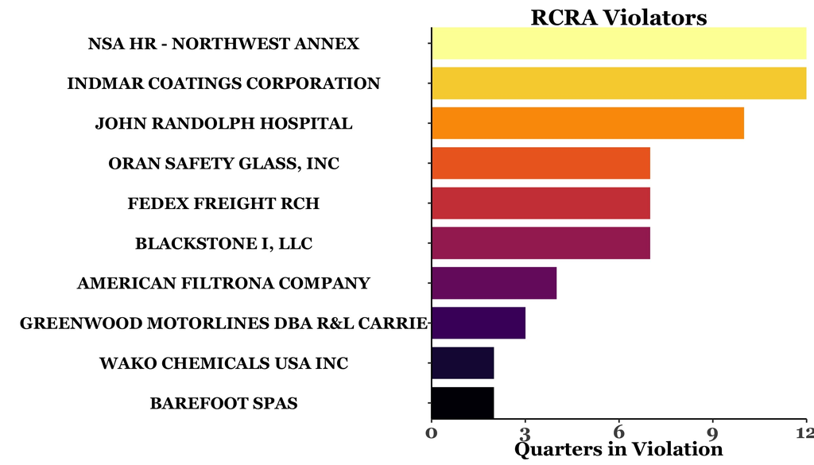

### ECHO reports for these facilities:

- [INDMAR COATINGS CORPORATION](http://echo.epa.gov/detailed-facility-report?fid=110020746512)
- [NSA HR - NORTHWEST ANNEX](http://echo.epa.gov/detailed-facility-report?fid=110012835281)
- [JOHN RANDOLPH HOSPITAL](http://echo.epa.gov/detailed-facility-report?fid=110001892658)
- [ORAN SAFETY GLASS, INC](http://echo.epa.gov/detailed-facility-report?fid=110070284762)
- [BLACKSTONE I, LLC](http://echo.epa.gov/detailed-facility-report?fid=110007019555)
- [FEDEX FREIGHT RCH](http://echo.epa.gov/detailed-facility-report?fid=110070206996)
- [AMERICAN FILTRONA COMPANY](http://echo.epa.gov/detailed-facility-report?fid=110004822675)
- [GREENWOOD MOTORLINES DBA R&L CARRIE](http://echo.epa.gov/detailed-facility-report?fid=110060291438)
- [WAKO CHEMICALS USA INC](http://echo.epa.gov/detailed-facility-report?fid=110000341979)
- [BAREFOOT SPAS](http://echo.epa.gov/detailed-facility-report?fid=110069459393)

#### DRAFT not for circulation

# Introduction

## Why

It is Congress’s job to oversee how the laws it passes are implemented by agencies like the Environmental Protection Agency (EPA). Congress has charged the EPA with enforcing most of the laws that protect environmental health by controlling the release of pollution and hazardous materials into the air, water and land. Without effective enforcement, **these laws are meaningless**. Congress can strengthen EPA enforcement by increasing resources to the EPA, passing more effective laws, requiring better data collection, and general oversight. In the **House of Representatives**, the **Energy and Commerce Committee** is the main committee that oversees the EPA. In the **Senate**, the **Environment and Public Works Committee** is the main committee that oversees the EPA.